# Project Checkpoint 6

**NAMES:** Madeline Abbott, Aidan Teppema, Daisy Cho

# Progress Made:

We updated the frequency model as our main model. We attempted running both spBayes and Poisson regression models and decided our data is more suited for Poisson regression. We also tested our poisson model and plotted the running mean plots.

# Group Member Roles:

- Madeline– Normal-Normal frequency model and poisson regression for frequency
- Daisy– Still looking into how to find only landfall coordinates and updating duration model
- Aidan– Also researched and ran poisson regression and spBayes.

# Modeling:

## Question 1.

To do:

- simple normal normal frequency model
- poisson regression
- spBayes location model

Things to consider:

- histogram of frequency
- also try frequency of hurricanes by certain location
- look at credible intervals of posterior to see if variables are useful
- length of simulation (n = 1000 or longer?)
- try using poisson instead of normal prior
- no linear structure–hurricances by year
- bivariate normal dist–gaussian dist for lat long coords
- modeling for seasonal point processess marked hurricane occurances
- intensity over time
- geoR–bayesian kriging
- poisson point process–modeling number of hurricanes per year by lat and long, over time predict rate with lat, long, and interaction
- THIS: look at non linearlity in hurricanes per year; lm in spBayes

Can we model the change in frequency of hurricanes based on trends in hurricane windspeed and category, temperature, CO2, and NAO index?

Plot histogram of annual hurricane frequency

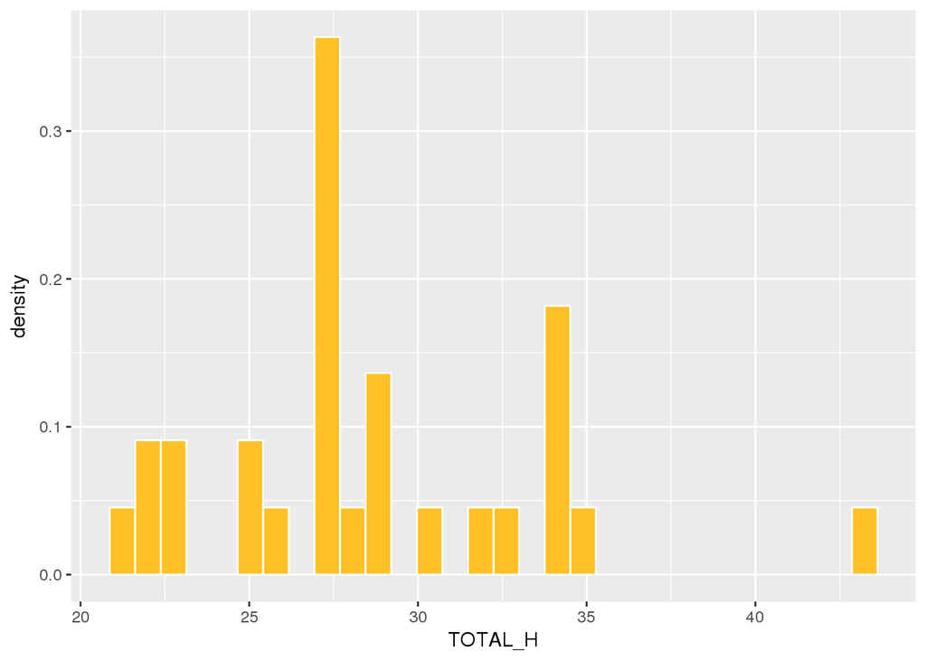

```r
# hurricanes
ggplot(hurricanes_per_year_clean, aes(x = TOTAL_H)) + geom_histogram(color = 'white', fill = 'goldenrod1', aes(y = ..density..))
```

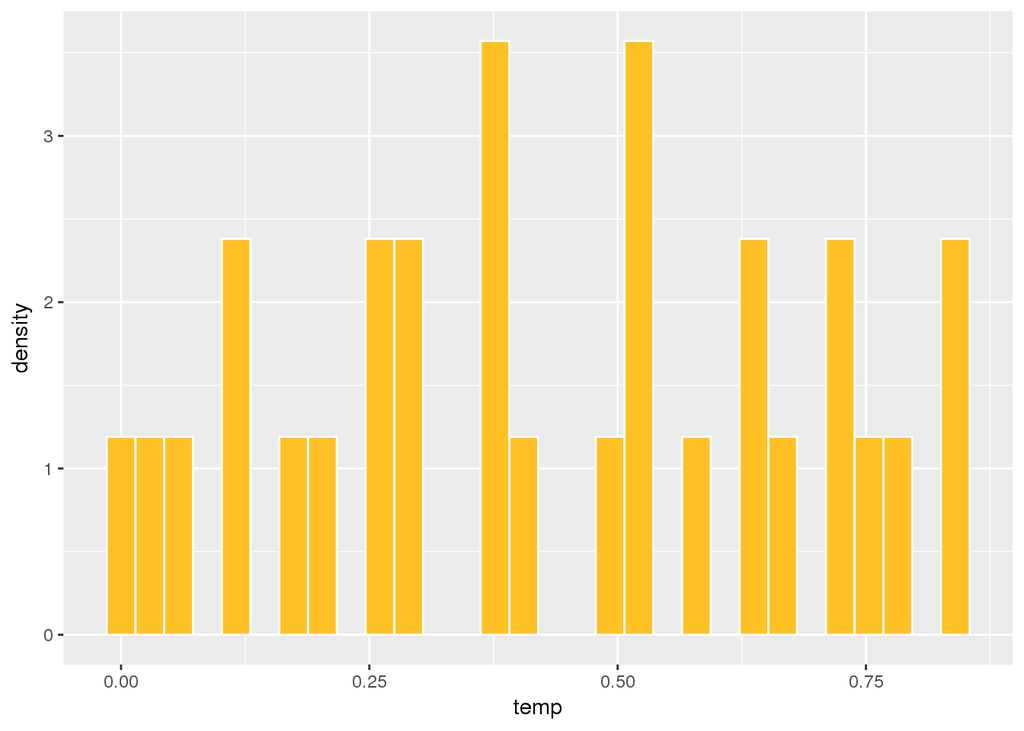

```r
# temp
ggplot(hurricanes_per_year_clean, aes(x = temp)) + geom_histogram(color = 'white', fill = 'goldenrod1', aes(y = ..density..))
```

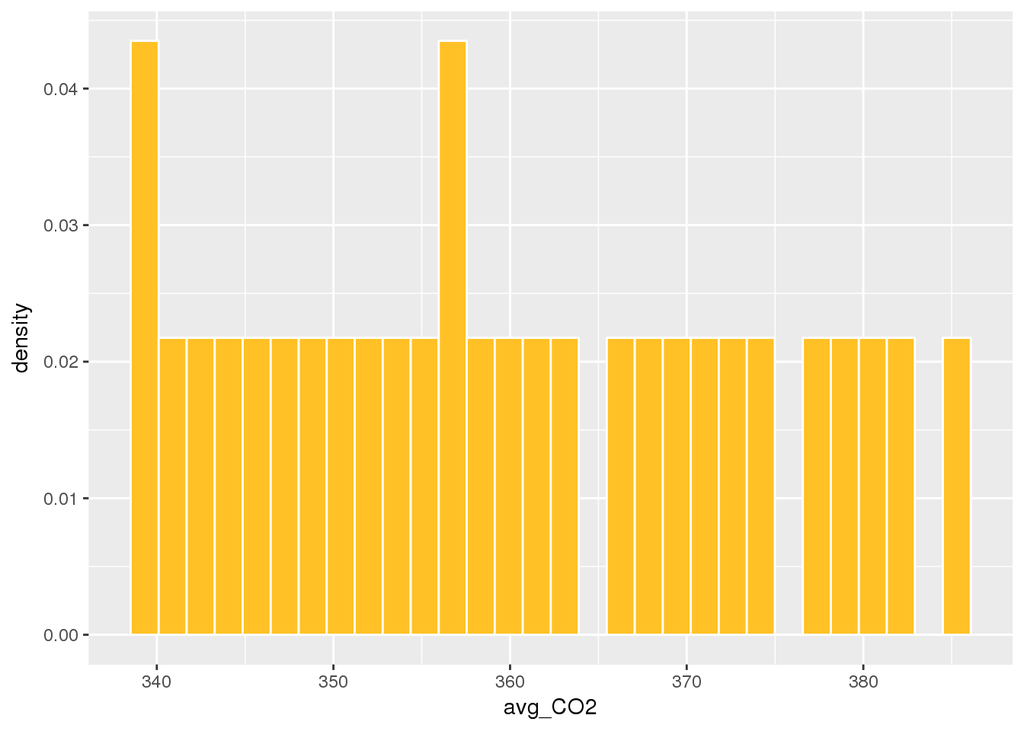

```r
#co2
ggplot(hurricanes_per_year_clean, aes(x = avg_CO2)) + geom_histogram(color = 'white', fill = 'goldenrod1', aes(y = ..density..))
```

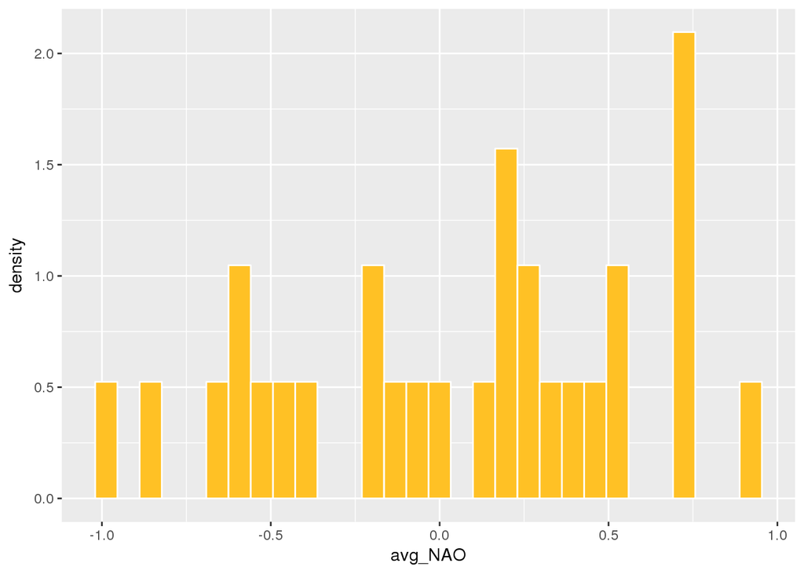

```r
# NAO
ggplot(hurricanes_per_year_clean, aes(x = avg_NAO)) + geom_histogram(color = 'white', fill = 'goldenrod1', aes(y = ..density..))
```

Plot distribution of variable per year

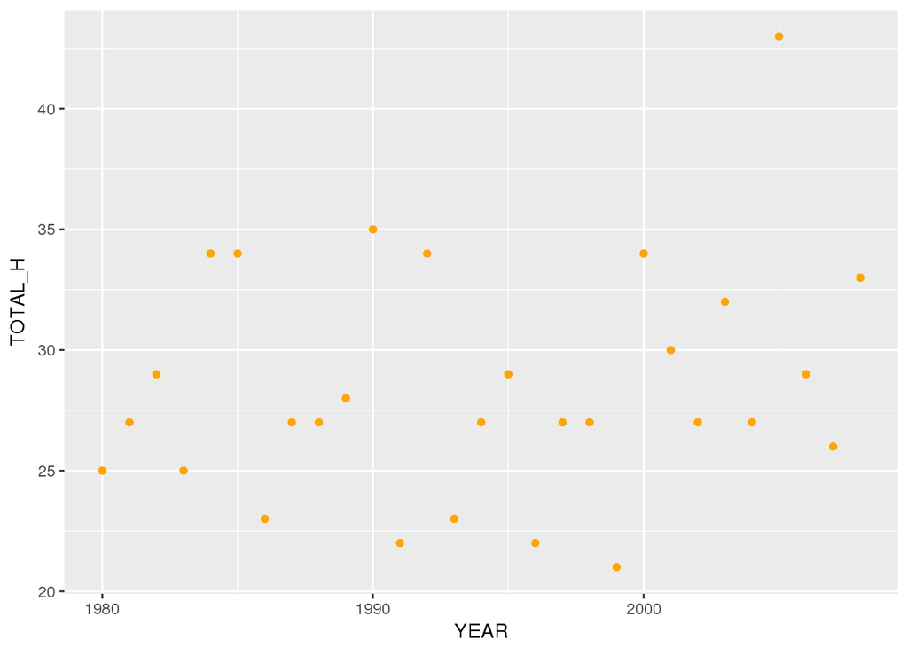

```r
#hurricanes
ggplot(hurricanes_per_year_clean, aes(x = YEAR, y = TOTAL_H)) + geom_point(color = "orange")
```

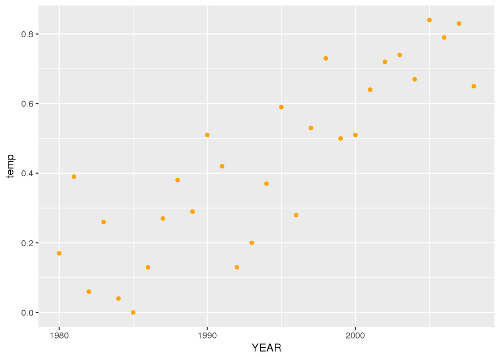

```r
# temp
ggplot(hurricanes_per_year_clean, aes(x = YEAR, y = temp)) + geom_point(color = "orange")
```

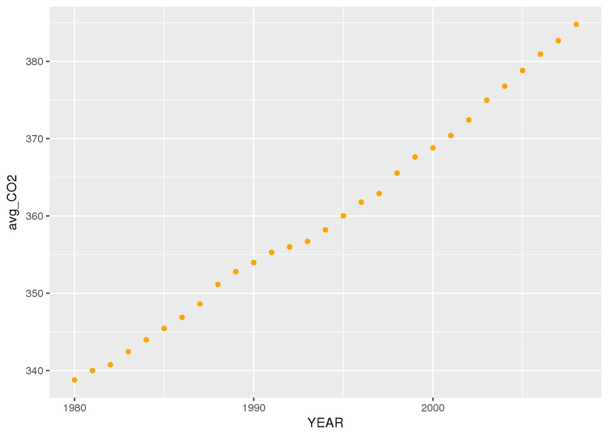

```r
# co2
ggplot(hurricanes_per_year_clean, aes(x = YEAR, y = avg_CO2)) + geom_point(color = "orange")
```

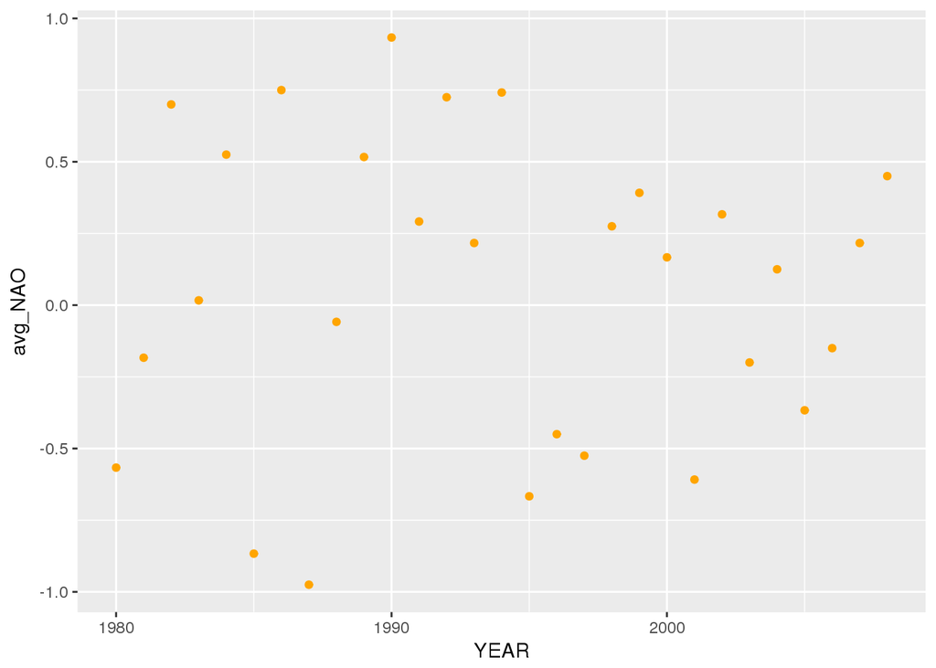

```r
# NAO
ggplot(hurricanes_per_year_clean, aes(x = YEAR, y = avg_NAO)) + geom_point(color = "orange")
```

Plot hurricanes per year by temperature

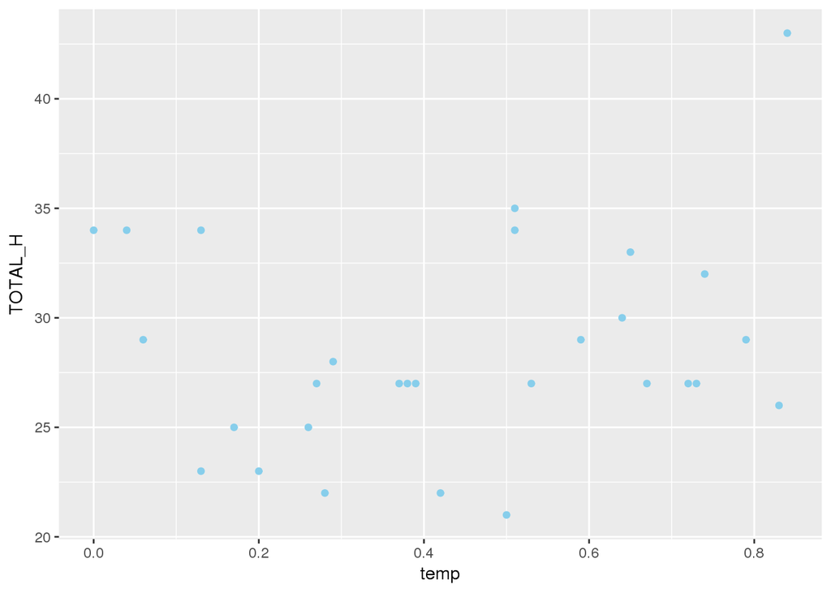

```r
ggplot(hurricanes_per_year_clean, aes(x = temp, y = TOTAL_H)) + geom_point(color = "skyblue")
```

Hurricanes per year by CO2 levels

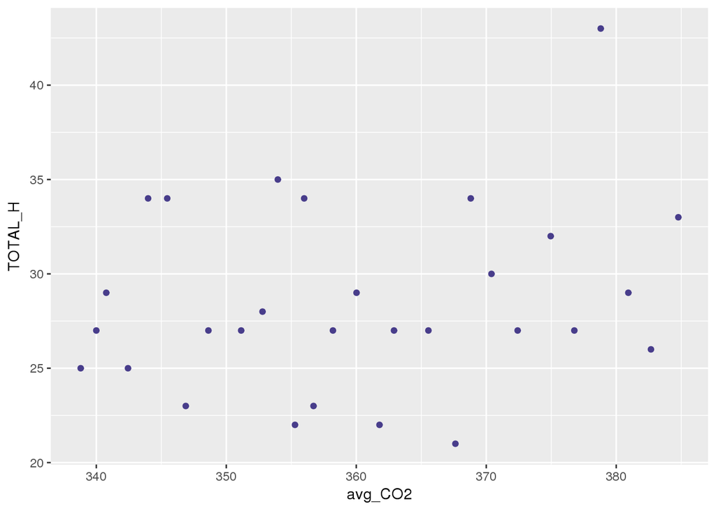

```r
ggplot(hurricanes_per_year_clean, aes(x = avg_CO2, y = TOTAL_H)) + geom_point(color = "darkslateblue")
```

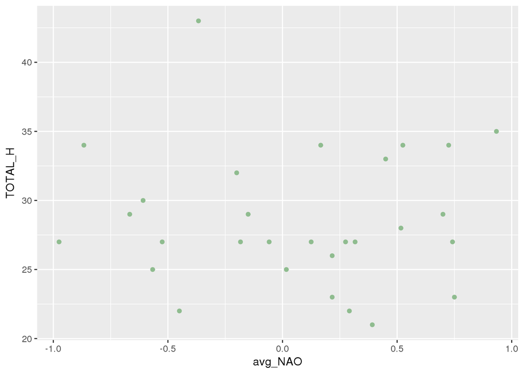

```r
ggplot(hurricanes_per_year_clean, aes(x = avg_NAO, y = TOTAL_H)) + geom_point(color = "darkseagreen")
```

### Model 1:

Let:

$Y_{t} =$ total hurricanes in year $t$

$X_{1t} =$ average yearly temperature in year $t$

$X_{2t} =$ yearly CO2 concentration in year $t$

$X_{3t} =$ NAO index in year $t$

We propose the following model:

$$Y_t | \beta_{0}, \beta_{1}, \beta_{2}, \beta_{3} \sim N(\beta_0 + \beta_{1}X_{1t} + \beta_{2}X_{2t} + \beta_{3}X_{3t}, \theta^2)$$

$$\beta_0 \sim N(0, 1000^2)$$

$$\beta_{1} \sim N(0, 1000^2)$$

$$\beta_{2} \sim N(0, 1000^2)$$

$$\beta_{3} \sim N(0, 1000^2)$$

$$(\theta^2)^{-1} \sim Gamma(0.001, 0.001)$$

### normal normal

```r
# specify the model
hurricane_freq_model1 <- "model{
  # Data
  for (t in 1:length(y)) {
    y[t] ~ dnorm(beta0 + beta1*x1[t] + beta2*x2[t] + beta3*x3[t], tau) #PRECISION
    }

  #Priors
  beta0 ~ dnorm(0, 1/(1000)^2) #PRECISION
  beta1 ~ dnorm(0, 1/(1000)^2) #PRECISION
  beta2 ~ dnorm(0, 1/(1000)^2) #PRECISION
  beta3 ~ dnorm(0, 1/(1000)^2) #PRECISION
  tau ~ dgamma(0.001, 0.001)
}"


# set up an algorithm to simulate the posterior by combining the model (hurricane_freq_model1) and data (y)
# set the random number seed
hurricane_freq_jags1 <- jags.model(textConnection(hurricane_freq_model1), data=list(y=hurricanes_per_year_clean$TOTAL_H, x1=hurricanes_per_year_clean$temp, x2=hurricanes_per_year_clean$avg_CO2, x3=hurricanes_per_year_clean$avg_NAO), inits=list(.RNG.name="base::Wichmann-Hill", .RNG.seed=1989))
# simulate a sample from the posterior
# note that we specify both mu and tau variables
hurricane_freq_sim1 <- coda.samples(hurricane_freq_jags1, variable.names = c("beta0", "beta1", "beta2", "beta3", "tau"), n.iter=10000)

# store the samples in a data frame:
hurricane_freq_sample1 <- data.frame(step = 1:10000, hurricane_freq_sim1[[1]])
head(hurricane_freq_sample1)
```

```
##   step    beta0       beta1        beta2      beta3        tau
## 1    1 28.58091  0.94920765 -0.001618171 -0.6482815 0.04500643
## 2    2 28.99950  0.03694807 -0.001644783  1.3987265 0.04394003
## 3    3 29.42818 -1.58509355 -0.003859894  1.7110183 0.03028684
## 4    4 30.23864  1.29081225 -0.011285911  1.3611877 0.03291065
## 5    5 31.03858  7.76288928 -0.015294501  2.4275049 0.02529937
## 6    6 32.27383  9.28294201 -0.024432289  2.0069144 0.06289704
```

```r
summary(hurricane_freq_sim1)
```

```
##
## Iterations = 1:10000
## Thinning interval = 1
## Number of chains = 1
## Sample size per chain = 10000
##
## 1. Empirical mean and standard deviation for each variable,
##    plus standard error of the mean:
##
##           Mean       SD  Naive SE Time-series SE
## beta0 20.30080 22.63082 0.2263082       7.190529
## beta1  2.40783  4.99171 0.0499171       0.497531
## beta2  0.01997  0.06650 0.0006650       0.022528
## beta3 -0.09969  1.88713 0.0188713       0.020114
## tau    0.04062  0.01119 0.0001119       0.000129
##
## 2. Quantiles for each variable:
##
##            2.5%      25%      50%      75%    97.5%
## beta0 -23.54208  4.59062 18.70974 35.73645 64.12662
## beta1  -7.46784 -0.95703  2.46435  5.73975 12.20657
## beta2  -0.10701 -0.02498  0.02346  0.06644  0.14801
## beta3  -3.81514 -1.34731 -0.08248  1.13841  3.60804
## tau     0.02178  0.03271  0.03958  0.04736  0.06523
```

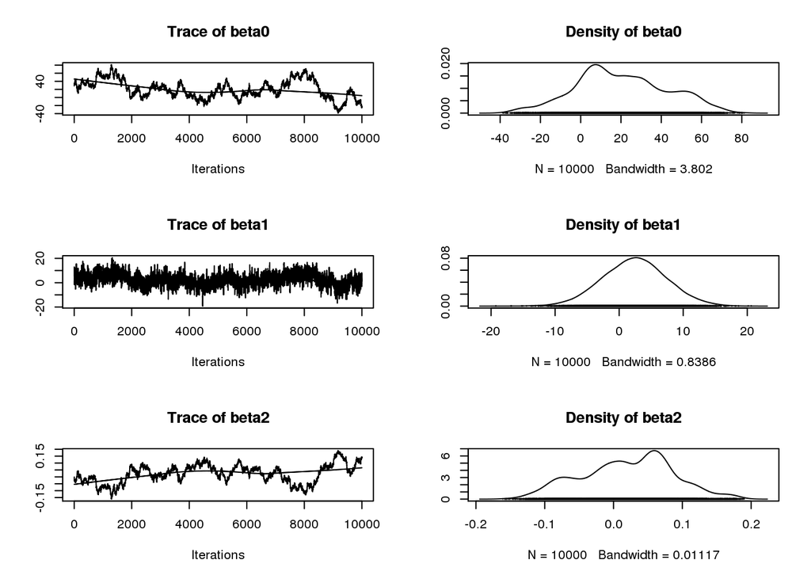

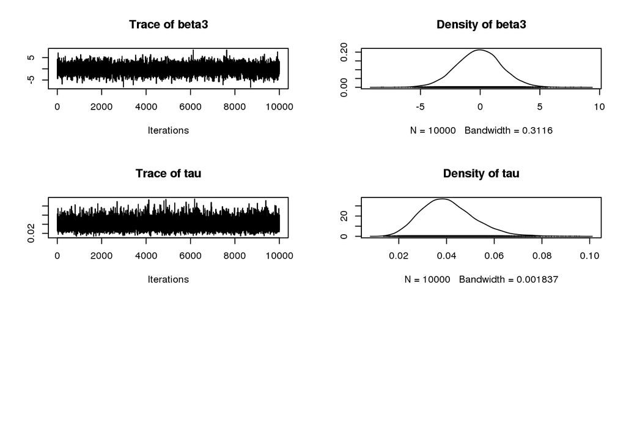

```r
plot(hurricane_freq_sim1)
```

Try spBayes–nope because we don’t have the right sort of data

```r
# could also do this with landfall location instead of location max

#View(hurricane_data) # checking our data

library(dplyr)

# table of locations where wind speed in max.  in cases where hurricane has multiple obervations at max wind speed, the center of these list locations is given as location of max wind speed
location_max <- hurricane_data %>%
  filter(YEAR > 1949) %>%
  group_by(YEAR, NAME) %>%
  filter(WIND_KTS == max(WIND_KTS)) %>%
  summarise(CENTER_LAT = mean(LAT), CENTER_LONG = mean(LONG), WIND_KTS = mean(WIND_KTS))


# create a matrix of coordinates
storms_locs <- location_max[,c("CENTER_LONG", "CENTER_LAT")]
```

Try poisson regression

```r
library(rjags)

head(location_max)
```

```
## # A tibble: 6 x 5
## # Groups:   YEAR [1]
##    YEAR    NAME CENTER_LAT CENTER_LONG WIND_KTS
##   <int>   <chr>      <dbl>       <dbl>    <dbl>
## 1  1950    ABLE   29.23333   -75.36667      120
## 2  1950   BAKER   16.70000   -60.00000      105
## 3  1950 CHARLIE   30.26667   -57.70000      100
## 4  1950     DOG   27.26667   -68.26667      160
## 5  1950    EASY   27.76667   -83.36667      110
## 6  1950     FOX   26.25000   -59.65000      120
```

```r
head(hurricanes_per_year_clean)
```

```
##    YEAR TOTAL_H temp  avg_CO2     avg_NAO
## 31 1980      25 0.17 338.7967 -0.56666667
## 32 1981      27 0.39 339.9975 -0.18333333
## 33 1982      29 0.06 340.7633  0.70000000
## 34 1983      25 0.26 342.4367  0.01666667
## 35 1984      34 0.04 343.9833  0.52500000
## 36 1985      34 0.00 345.4550 -0.86666667
```

```r
hur_mod <- " model {
  for (i in 1:length(TOTAL_H)) {
      TOTAL_H[i] ~ dpois(lam[i])
      log(lam[i]) = beta0 + beta1*X1[i] + beta2*X2[i] + beta3*X3[i]
  }

  beta0 ~ dnorm(0.0, 1.0/1e6)
  beta1 ~ dnorm(0.0, 1.0/1e4)
  beta2 ~ dnorm(0.0, 1.0/1e4)
  beta3 ~ dnorm(0.0, 1.0/1e4)
} "

# set up an algorithm to simulate the posterior by combining the model and data (x)
# set the random number seed

data_jags = as.list(hurricanes_per_year_clean[,2:5])
str(data_jags)
```

```
## List of 4
##  $ TOTAL_H: int [1:29] 25 27 29 25 34 34 23 27 27 28 ...
##  $ temp   : num [1:29] 0.17 0.39 0.06 0.26 0.04 0 0.13 0.27 0.38 0.29 ...
##  $ avg_CO2: num [1:29] 339 340 341 342 344 ...
##  $ avg_NAO: num [1:29] -0.5667 -0.1833 0.7 0.0167 0.525 ...
```

```r
freq_jags <- jags.model(textConnection(hur_mod),data=list(TOTAL_H = hurricanes_per_year_clean$TOTAL_H, X1 = hurricanes_per_year_clean$temp, X2 = hurricanes_per_year_clean$avg_CO2,X3 = hurricanes_per_year_clean$avg_NAO), inits=list(.RNG.name="base::Wichmann-Hill", .RNG.seed=2000))
# simulate a sample from the posterior
# note that we specify both mu and tau variables
freq_sim <- coda.samples(freq_jags, variable.names = c("beta0", "beta1", "beta2", "beta3"), n.iter=50000)

# store the samples in a data frame:
freq_sample <- data.frame(step = 1:50000, freq_sim[[1]])
head(freq_sample)
```

```
##   step    beta0      beta1        beta2         beta3
## 1    1 4.062907 0.17550675 -0.002242670 -0.0151960164
## 2    2 4.097669 0.15725828 -0.002230139  0.0011688406
## 3    3 4.104355 0.11863140 -0.002161106  0.0007125178
## 4    4 4.150869 0.05588128 -0.002291257 -0.0044433942
## 5    5 4.089914 0.20640267 -0.002344497  0.0266518887
## 6    6 4.123086 0.20980289 -0.002279306 -0.0725420653
```

Looking at convergence

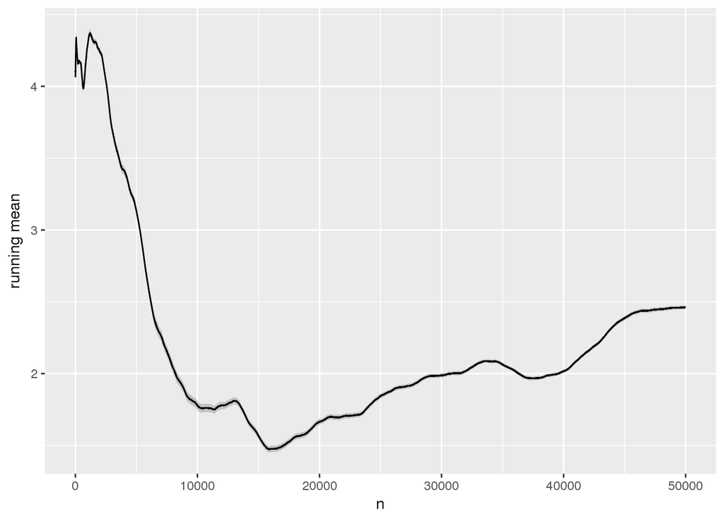

```r
library(MacBayes)
running_mean_plot(x=freq_sample$beta0, se=TRUE)
```

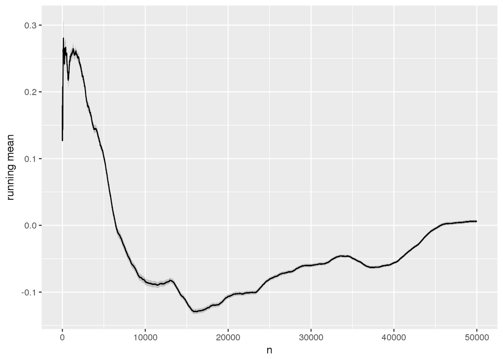

```r
running_mean_plot(x=freq_sample$beta1, se=TRUE)
```

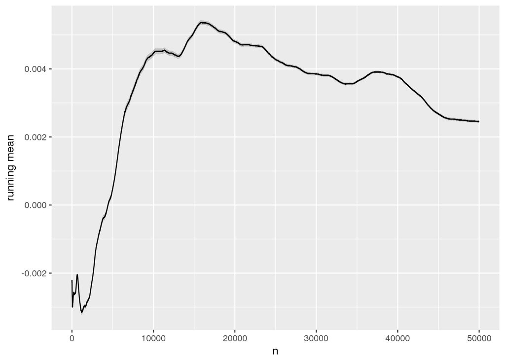

```r
running_mean_plot(x=freq_sample$beta2, se=TRUE)
```

Testing

```r
exp(quantile(freq_sample$beta1, c(0.05, 0.975)))
```

```
##        5%     97.5%
## 0.6581385 1.7288128
```

```r
exp(quantile(freq_sample$beta2, c(0.05, 0.975)))
```

```
##        5%     97.5%
## 0.9941828 1.0112944
```

```r
exp(quantile(freq_sample$beta3, c(0.05, 0.975)))
```

```
##        5%     97.5%
## 0.8871741 1.1399576
```

```r
mean(freq_sample$beta0)
```

```
## [1] 2.462726
```

```r
mean(freq_sample$beta1)
```

```
## [1] 0.006189923
```

```r
mean(freq_sample$beta2)
```

```
## [1] 0.002452057
```

```r
mean(freq_sample$beta3)
```

```
## [1] -0.006030371
```

Landfall locations

```r
storm_landfall <- read.csv("/Users/madelineabbott/Desktop/Bayes Capstone/stormData.csv")
```

## Question 2.

What is the duration of hurricanes per year based on the frequency model?

$$Y\sim \Gamma(\lambda_i, r)$$

I am trying to run a gamma likelihood parametrization, but it has not been fully completed yet so it should not be running.

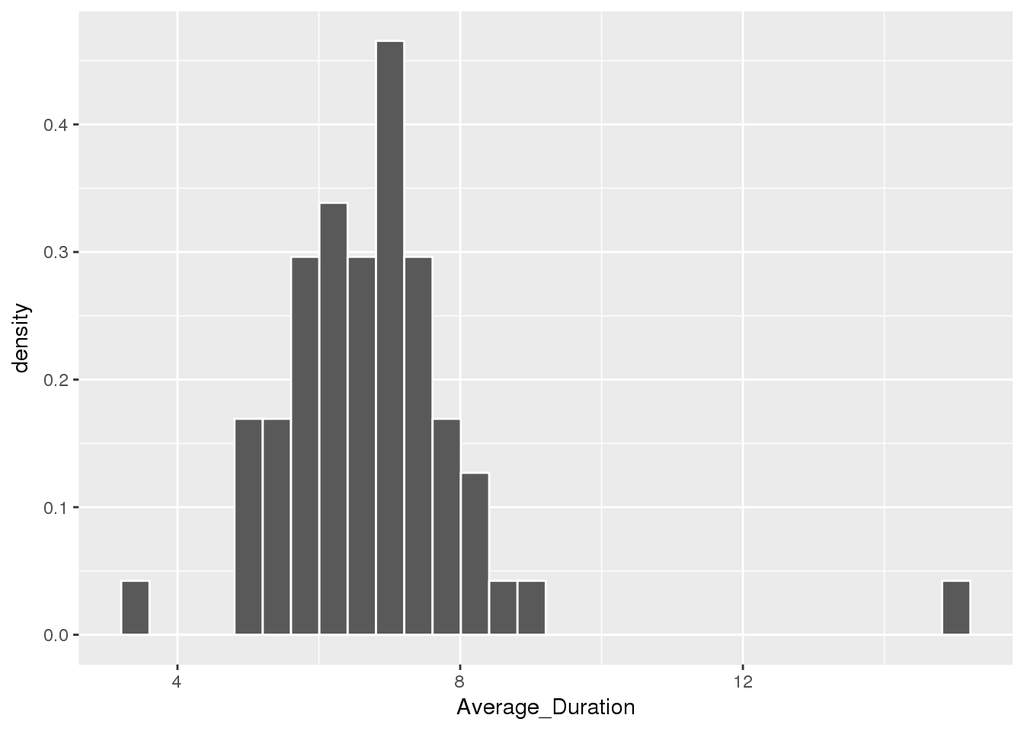

```r
hurricanes_recent<-recent_hurricanes[!(recent_hurricanes$NAME=="NOTNAMED"),]

# Hurricane data only looking at Date and name
hurricane_time<-subset(hurricanes_recent, select = c(NAME,YEAR,MONTH,DAY))

#Group data by year and name and subtracting starting time from end time for each hurricane (duration)
foo <- hurricane_time %>%
  group_by(YEAR, NAME) %>%
  mutate(date = as.Date(paste(YEAR, MONTH, DAY, sep='-')), "%Y-%m-%d") %>%
  summarise(duration = max(date) - min(date))

#removed outlier
foo<-foo[!(foo$YEAR==1954 & foo$NAME=="ALICE"),]

# Averaging duration per year
foo<-group_by(foo, YEAR)%>%
  summarise(mean(duration))
colnames(foo)[2] <- "Average_Duration"
ggplot(foo, aes(x=Average_Duration))+
  geom_histogram(boundary=0,color="white", aes(y=..density..))
```

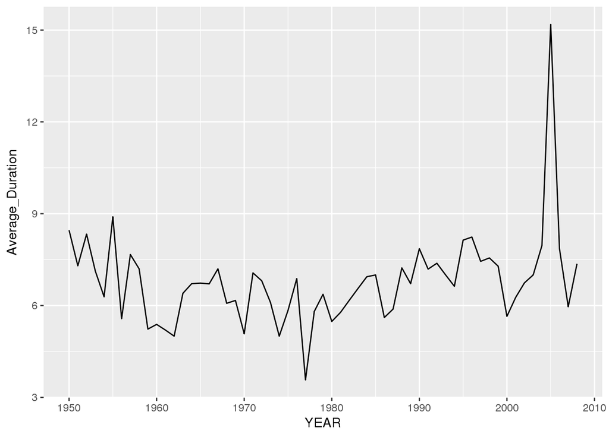

```r
ggplot(foo,aes(x=YEAR, y=Average_Duration))+
  geom_line()
```

```r
library(rjags)

head(location_max)
head(hurricanes_per_year_clean)

duration_mod <- " model {
  for (i in 1:length(TOTAL_H)) {
      y[i] ~ dgamma(lam[i], b)
      log(lam[i]) = beta0 + beta1*X1[i] + beta2*X2[i] + beta3*X3[i]
  }
  r~dpois(1)
  beta0 ~ dnorm(0.0, 1.0/1e6)
  beta1 ~ dnorm(0.0, 1.0/1e4)
  beta2 ~ dnorm(0.0, 1.0/1e4)
  beta3 ~ dnorm(0.0, 1.0/1e4)
} "

# set up an algorithm to simulate the posterior by combining the model and data (x)
# set the random number seed

data_jags = as.list(foo[,2])
str(data_jags)

duration_jags <- jags.model(textConnection(hur_mod),data=list(y = foo$Average_Duration, X1 = hurricanes_per_year_clean$temp, X2 = hurricanes_per_year_clean$avg_CO2,X3 = hurricanes_per_year_clean$avg_NAO), inits=list(.RNG.name="base::Wichmann-Hill", .RNG.seed=2000))

# simulate a sample from the posterior
# note that we specify both mu and tau variables
duration_sim <- coda.samples(duration_jags, variable.names = c("r", "beta0", "beta1", "beta2", "beta3"), n.iter=50000)

# store the samples in a data frame:
duration_sample <- data.frame(step = 1:50000, freq_sim[[1]])
head(duration_sample)
```